# 2A: East Bay Pond Water

Author

Caitlin Nordheim-Maestas

# Load in data and libraries

```r
## read in and clean data
library(tidyverse) # for cleaning and viewing data
library(gt) # pretty stats tables
library(broom) # cleaning for gt
library(here) # for importing data
library(car) # stats tests like Levene's
library(Hmisc) # autocalculate stat summaries in ggplot
library(multcomp) # stats
library(nlme) # mixed effects models
library(emmeans) # for pairwise comparisons, especially on mixed effects models and glms
library(ggpubr) # for making ggqq plot
library(patchwork) # for combining figures

# load data
fs_pw_bd <- read.csv(here("data", "fifteen-sites-PW-on-Bd - Sheet1.csv"))
fig_2b_raw <- read.csv(here("data", "final_NCOS_2024_reformatted_for_R.xlsx - Fig2B.csv"))

# Colors: these are from Paul Tol's colorblind friendly palette
with_microbes_40_color <- "#999933"
no_microbes_.22_color <- "#88ccee"

# set up custom theme
myCustomTheme <- function() {
  theme_light() +
    theme(axis.text = element_text(size = 12, family = "Times", color = "black"),
          axis.title.x = element_text(margin = margin(t = 10), size = 14, face = "bold", family = "Times", color = "black"), # Add space between x-axis label and axis
          axis.title.y = element_text(margin = margin(r = 10), size = 14, face = "bold", family = "Times", color = "black"), # Add space between y-axis label and axis
          title = element_text(size = 12, face = "bold", family = "Times"),
          plot.caption = element_text(size = 10, face = "italic", family = "Times"),
          legend.text = element_text(size = 10, family = "Times"), # Increase legend text size
          panel.grid.major.x = element_blank(), # Remove major vertical grid lines
          panel.grid.minor.x = element_blank(), # Remove minor vertical grid lines
          panel.grid.major.y = element_blank(), # Remove major horizontal grid lines
          panel.grid.minor.y = element_blank(), # Remove minor horizontal grid lines
          strip.text = element_text(size = 12, face = "bold", family = "Times", color = "black"), # Set strip text style
          strip.background = element_rect(fill = "white", color = "grey"), # Set strip background to white, # color = "black"
          axis.ticks = element_blank() # Remove x and y axis ticks
    )}
```

# 2A

## Data Wrangling

```r
# remove controls
eb_pw <- fs_pw_bd %>% filter(site != "sterile MQ")

# keep control for labeling plot
eb_pw_controls <- fs_pw_bd %>%
  filter(site =="sterile MQ") %>%
  pivot_wider(names_from = bd_location, values_from = bd_qty) %>%
  mutate(combined_bd = adherent + floating) %>%
   mutate(day = case_when(
    day == 1 ~ "Day_1",
    day == 7 ~ "Day_7"))

# data type cleaning
eb_pw$bd_location <- factor(eb_pw$bd_location, levels = c("floating", "adherent"))
eb_pw$filter <- factor(eb_pw$filter,
                          levels = c("40um_filter", "0.22um_filter"))
eb_pw$day <- factor(eb_pw$day, levels = c("1", "7"),
                            labels = c("Day_1", "Day_7"))
eb_pw$site <- factor(eb_pw$site,
                          levels = c("BARN", "CABIN", "NORTH", "GRAMPS", "WEST", "GDPND004", "GDPND005", "GDPND006", "GDPND008", "GDPND009", "PRPND002", "PRPND003", "PRPND004", "PRPND009", "PRPND010", "sterile MQ"))

# get the total difference across days by combining both locations of Bd then subtracting across days
eb_pw_total_diff <- eb_pw %>%
  # combine floating and adherent for total_Bd
  pivot_wider(names_from = bd_location, values_from = bd_qty) %>%
  mutate(combined_bd = adherent + floating) %>%
  subset(select = -c(adherent,floating)) %>%

# different metrics of difference in Bd
  pivot_wider(names_from = day, values_from = combined_bd) %>%

  # calculate the rate loss by taking the log of each before subtracting
  mutate(rate_loss = log(Day_1) - log(Day_7))

# Split into 2 data frames one for 40 and one for .22
eb_pw_total_diff_40um <- eb_pw_total_diff %>%
  filter(filter =="40um_filter")
eb_pw_total_diff.22um <- eb_pw_total_diff%>%
  filter(filter =="0.22um_filter")
```

## EDA

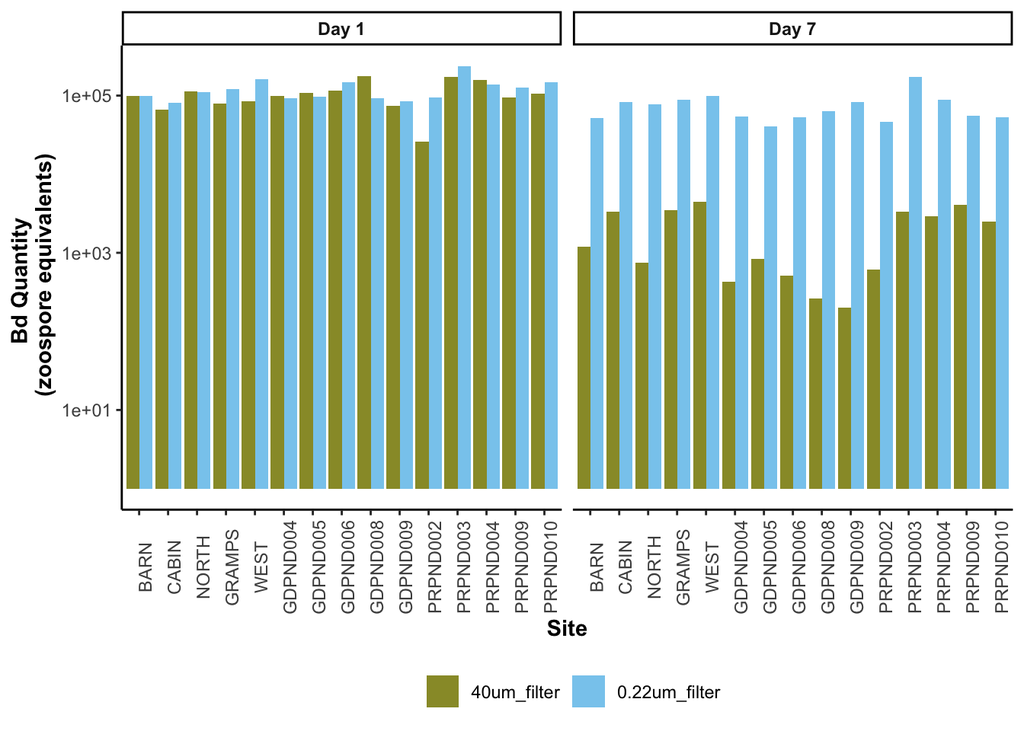

```r
# Renwei barplot remake
eb_pw %>%
  # combine floating and adherent for total_Bd
  pivot_wider(names_from = bd_location, values_from = bd_qty) %>%
  mutate(combined_bd = adherent + floating) %>%
ggplot(aes(y= combined_bd, x = site, fill = filter)) +
    geom_col(position = position_dodge()) +
  scale_y_log10() +
    facet_wrap(~day, labeller = labeller(day = c("Day_1" = "Day 1",
                                                    "Day_7" = "Day 7"))) +
  scale_fill_manual(values = c("40um_filter" = with_microbes_40_color,
                                "0.22um_filter" = no_microbes_.22_color)) +
    theme_classic() +
   theme(axis.text.x = element_text(angle = 90),
        legend.position = "bottom",
         strip.text = element_text(face="bold"),
         axis.title = element_text(face = "bold")) +
    xlab("Site") +
    ylab("Bd Quantity \n (zoospore equivalents)") +
  guides(fill=guide_legend(title=""))
```

Boxplot

```r
# eb_pw %>%
#   # combine floating and adherent for total_Bd
#   pivot_wider(names_from = bd_location, values_from = bd_qty) %>%
#   mutate(combined_bd = adherent + floating) %>%
#
#   # create the plot
#   ggplot(aes(y= combined_bd, x = filter, fill = filter)) +
#     geom_boxplot() +
#   geom_jitter(width = 0.2, alpha = 0.3) +
#     scale_y_log10() +
#     facet_wrap(~day, labeller = labeller(day = c("Day_1" = "Day 1",
#                                                     "Day_7" = "Day 7")))+
#   scale_fill_manual(values = c("40um_filter" = with_microbes_40_color,
#                                 "0.22um_filter" = no_microbes_.22_color)) +
#     theme_classic() +
#    theme(legend.position = "none",
#          strip.text = element_text(face="bold"),
#          axis.title = element_text(face = "bold")) +
#   scale_x_discrete (labels= c("40um_filter" = "With Microbes", "0.22um_filter" = "No Microbes")) +
#     xlab("Presence of Microbes in Pond Water") +
#     ylab("Bd Quantity \n (zoospore equivalents)") +
#
#   # add controls ad x's
#   geom_point(data = eb_pw_controls, aes(x = filter, y = combined_bd), shape = 4, size = 2)
```

## Stats and assumption testing

**Statistical question**: Is there a difference in the **rate of gain or loss of Bd over 6 days** between the **filter sizes** looking at the **TOTAL BD**

The samples are essentially paired by site, so a paired t-test is most appropriate

$H0:μ_{difference in Bd}=0$

Assumptions:

Assumes that the observations from each group represent a random sample from the population. Assumes that the difference of the two observations follow a normal distribution.

Assumption testing:

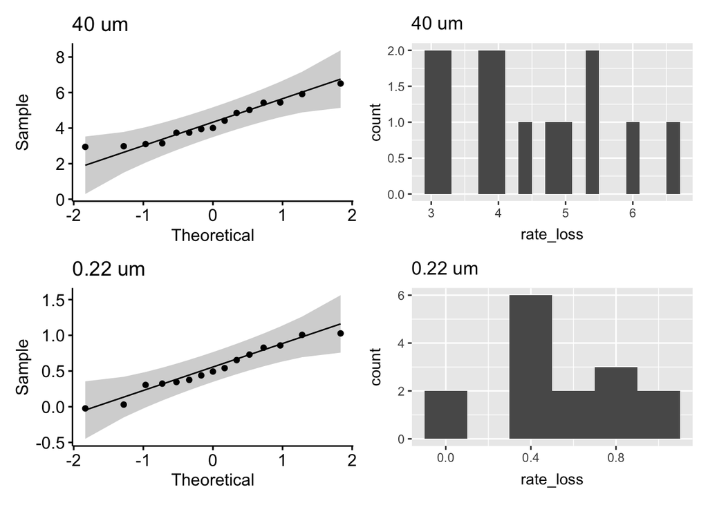

```r
# check normality of the differences across groups

# numeric check
eb_pw_40um_shapiro.test <- shapiro.test(eb_pw_total_diff_40um$rate_loss) # normal, yay!
eb_pw_0.22um_shapiro.test <- shapiro.test(eb_pw_total_diff.22um$rate_loss) # normal, yay!

# visual check
eb_pw_40um_qq <- eb_pw_total_diff_40um %>%
  ggqqplot("rate_loss", title = "40 um")

# Histogram using ggplot2
eb_pw_40um_hist <- eb_pw_total_diff_40um %>%
  ggplot(aes(x = rate_loss)) +
  geom_histogram(binwidth = 0.2) +
  labs(title = "40 um")

# visual check
eb_pw_0.22um_qq <- eb_pw_total_diff.22um %>%
  ggqqplot("rate_loss", title = "0.22 um")

# Histogram using ggplot2
eb_pw_0.22um_hist <- eb_pw_total_diff.22um %>%
  ggplot(aes(x = rate_loss)) +
  geom_histogram(binwidth = 0.2) +
  labs(title = "0.22 um")

eb_pw_40um_qq + eb_pw_40um_hist + eb_pw_0.22um_qq + eb_pw_0.22um_hist
```

```r
eb_pw_40um_shapiro.test
```

```
    Shapiro-Wilk normality test

data:  eb_pw_total_diff_40um$rate_loss
W = 0.93591, p-value = 0.3337
```

```r
eb_pw_0.22um_shapiro.test
```

```
    Shapiro-Wilk normality test

data:  eb_pw_total_diff.22um$rate_loss
W = 0.96119, p-value = 0.7131
```

The data for the 40um filter is normally distributed (Shapiro-Wilk test, W = 0.93591, p = 0.3337), and so is the data for the 0.22 filter (Shapiro-Wilk test, W = 0.96119, p = 0.7131).

```r
# Run the paired t-test on the difference
eb_pw_paired_ttest_result <- t.test(eb_pw_total_diff_40um$rate_loss, eb_pw_total_diff.22um$rate_loss, paired = TRUE)

eb_pw_paired_ttest_result
```

```
    Paired t-test

data:  eb_pw_total_diff_40um$rate_loss and eb_pw_total_diff.22um$rate_loss
t = 12.449, df = 14, p-value = 5.83e-09
alternative hypothesis: true mean difference is not equal to 0
95 percent confidence interval:
 3.159637 4.474996
sample estimates:
mean difference
       3.817316
```

**There is a significant difference in the change in the total quantity of Bd from Day 1 to Day 7 across the filter types (t = 12.4488129, df = 14, p-value = 5.8299032^{-9})**

The t-value is positive, which shows that the first item entered (with microbes) has a larger loss of Bd than the second item entered (no microbes.) Df of 14 is expected, because it’s 15 sites.

# 2b

# Data cleaning

```r
## 2B
pw <- fig_2b_raw %>%
  # add column for microbes or no
  mutate(microbes = case_when(
    str_detect(sample_ID, "\\+microorganism") ~ "y",
    TRUE ~ "n"
  )) %>%
  # # add column for water_treatment
  mutate(water_treatment = case_when(
    sample_ID %in% c("1%TB", "MQ", "Added Bd") ~ "sterile-water",
    sample_ID %in% c("1%TB+PW+microorganism", "PW+microorganism") ~ "PW+MO",
    sample_ID %in% c("1%TB+PW-microorganism", "PW-microorganism") ~ "PW-MO"
  )) %>%
  # add column for TB or no
  mutate(TB = case_when(
    str_detect(sample_ID, "TB") ~ "y",
    TRUE ~ "n"
  ))

pw_summary <- pw %>%
  group_by(day, sample_ID) %>%
  reframe(mean = mean(adh_plus_sup), # calculate the mean
            n = length(adh_plus_sup), # count the number of observations
            df = n - 1, # calculate the degrees of freedom
            sd = sd(adh_plus_sup), # calculate the standard deviation
            se = sd/sqrt(n), # calculate the standard error
          ) %>%
  mutate(microbes = case_when(
    str_detect(sample_ID, "\\+microorganism") ~ "y",TRUE ~ "n")) %>%
  # add column for TB or no
  mutate(TB = case_when(str_detect(sample_ID, "TB") ~ "y", TRUE ~ "n")) %>%
  # add column for PW or no
   mutate(water_treatment = case_when(
    sample_ID %in% c("1%TB", "MQ", "Added Bd") ~ "sterile-water",
    sample_ID %in% c("1%TB+PW+microorganism", "PW+microorganism") ~ "PW+MO",
    sample_ID %in% c("1%TB+PW-microorganism", "PW-microorganism") ~ "PW-MO"
  ))

pw_control_data <- pw %>%
  filter(day == 0) %>%
  dplyr::select(day, adh_plus_sup)

##### 2b #####
pw_noday0 <- pw %>%
  filter(day != 0) %>%
  mutate(log_adh_plus_sup = log(adh_plus_sup)) # note: no zeroes so not log + 1

# quick check: we want day as a FACTOR
pw_noday0 <- pw_noday0 %>%
  mutate(day = as.factor(day))

pw_noday0 <- pw_noday0 %>%
mutate(day = factor(day,
          levels = c("1", "3", "5", "7"), ordered = T))
str(pw_noday0$day)
```

```
 Ord.factor w/ 4 levels "1"<"3"<"5"<"7": 1 2 3 4 1 2 3 4 1 2 ...
```

```r
# set MQ as reference
pw_noday0$sample_ID <- factor(pw_noday0$sample_ID)
pw_noday0$sample_ID <- relevel(pw_noday0$sample_ID, ref = "MQ")

# set sterile water as reference
pw_noday0$water_treatment <- factor(pw_noday0$water_treatment)
pw_noday0$water_treatment <- relevel(pw_noday0$water_treatment, ref = "sterile-water")

# set no TB as reference
pw_noday0$TB <- factor(pw_noday0$TB)
pw_noday0$TB <- relevel(pw_noday0$TB, ref = "n")

# set no microbes as reference
pw_noday0$microbes <- factor(pw_noday0$microbes)
pw_noday0$microbes <- relevel(pw_noday0$microbes, ref = "n")
```

# 2b: NCOS Pond water

## Renwei’s figure

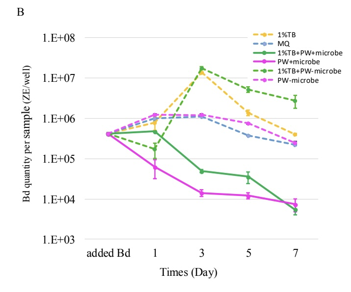

## Caitlin’s version

```r
fig_2b <- pw_summary %>%
  # reorder to match Renwei's plot
  mutate(sample_ID = factor(sample_ID,
                            levels = c("1%TB", "MQ", "1%TB+PW+microorganism", "PW+microorganism", "1%TB+PW-microorganism", "PW-microorganism", "Added Bd"))) %>%

  ggplot(aes(x = day,
           y = mean,
           color = sample_ID)) +
  geom_point(size = 2) +
  geom_errorbar(aes(ymin = mean - se, # plot the standard error
                    ymax = mean + se),
                width = 0.1) +
  scale_y_log10(limits = c(1e3, 1e8),
                breaks = c(1e3, 1e4, 1e5, 1e6, 1e7, 1e8)) +
  # vibes
 # vibes
  labs(x = "Day",
       y = "Bd Quantity per sample (ZE/well)",
       color = "Medium",       # Title for color legend
       linetype = "Microbes Present"  # Title for linetype legend
       ) +
  scale_color_manual(values = c("1%TB" = "#CCBB44",
                                "MQ" = "#228833",
                                "1%TB+PW+microorganism" = "#4477AA",
                                "PW+microorganism" = "#EE6677",
                                "1%TB+PW-microorganism" = "#66CCEE",
                                #"Added Bd" = "#BBBBBB" # removed bc not really a medium
                                "PW-microorganism" = "#AA3377"),  # Assign specific colors to match RC's plot
                    labels = c("1%TB" = "TB",
                                "MQ" = "MQ",
                                "1%TB+PW+microorganism" = "TB + PW + MO",
                                "PW+microorganism" = "PW + MO",
                                "1%TB+PW-microorganism" = "TB + PW - MO",
                                "PW-microorganism" = "PW - MO",
                                "Added Bd" = "Initial Bd")) + # Custom labels for the color legend
    geom_line(aes(linetype = microbes)) +
  scale_linetype_manual(values = c("n" = "dashed",
                                   "y" = "solid"),
                        labels = c("n" = "N", "y" = "Y")) +  # Change labels to uppercase N and Y
 myCustomTheme()+
  scale_x_continuous(breaks = c(0, 1, 3, 5, 7),
                   labels = c("Initial\nBd", "1", "3", "5", "7"))
  theme(legend.position = "right") # Adjust the legend position to overlap with the plot
```

## 2b EDA

visualize y var: bd load

log transformed will get me closer to normal, note we only need to worry about the residuals normality though, so commented out the transformation of the data for space

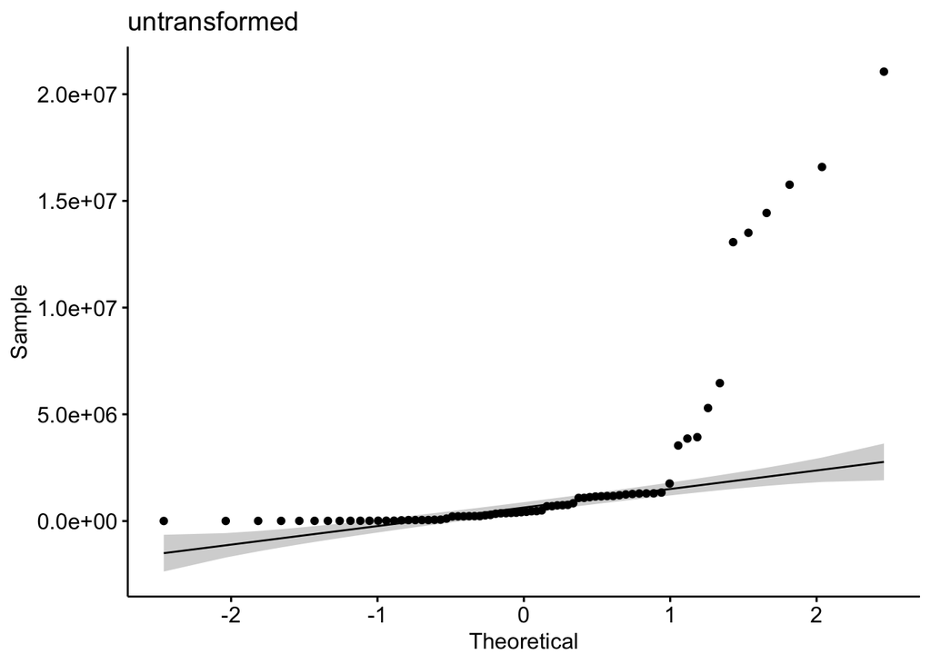

```r
# untransformed
ggqqplot(pw_noday0, "adh_plus_sup", title = "untransformed")
```

```r
shapiro.test(pw_noday0$adh_plus_sup) # nope
```

```
    Shapiro-Wilk normality test

data:  pw_noday0$adh_plus_sup
W = 0.49498, p-value = 2.434e-14
```

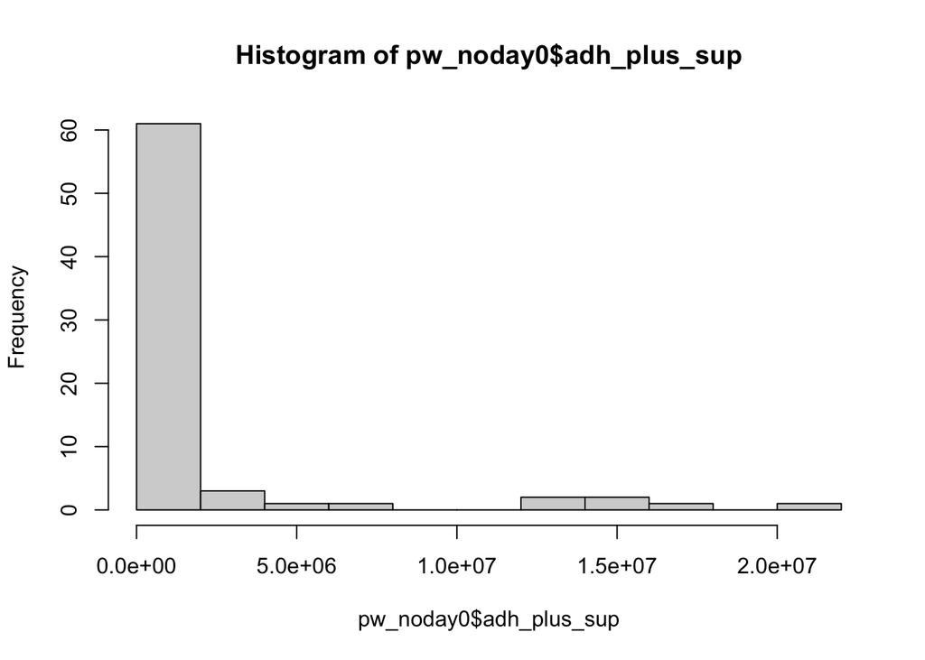

```r
hist(pw_noday0$adh_plus_sup) # note
```

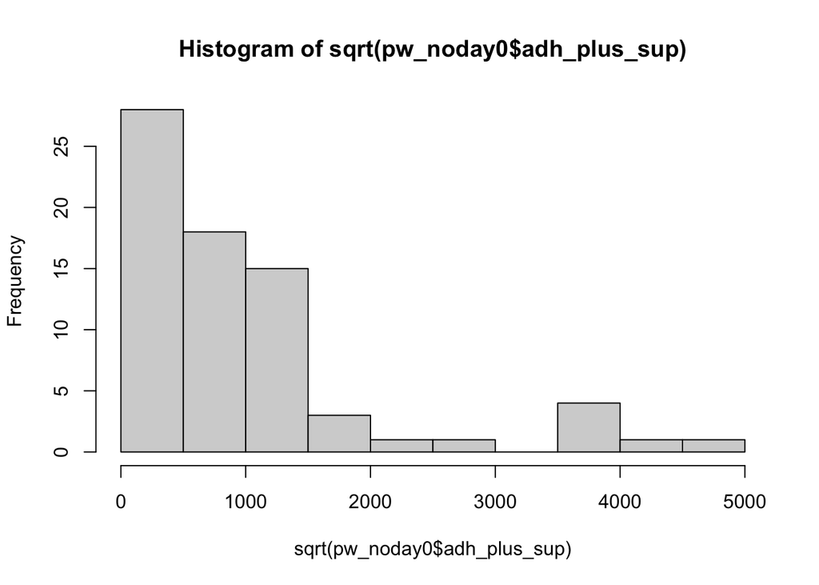

```r
hist(sqrt(pw_noday0$adh_plus_sup)) # nope
```

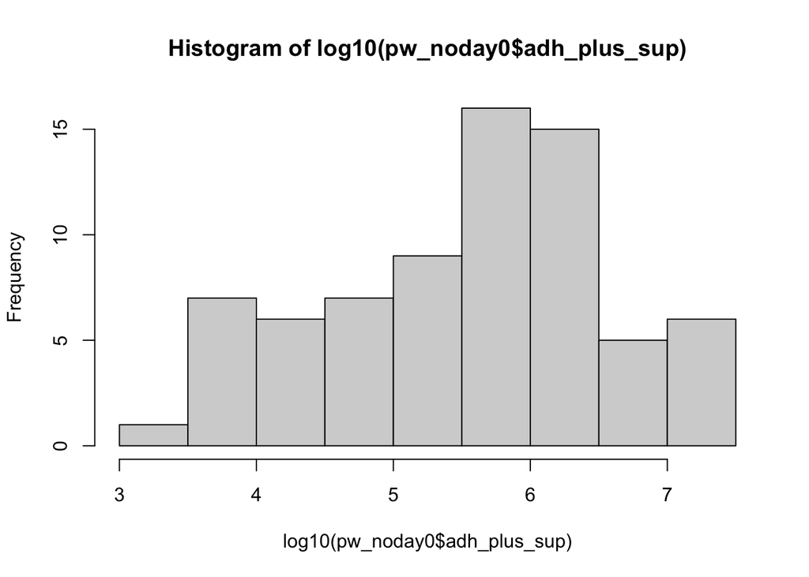

```r
hist(log10(pw_noday0$adh_plus_sup)) # much better...?
```

```r
shapiro.test(log10(pw_noday0$adh_plus_sup)) # not quite
```

```
    Shapiro-Wilk normality test

data:  log10(pw_noday0$adh_plus_sup)
W = 0.95623, p-value = 0.01361
```

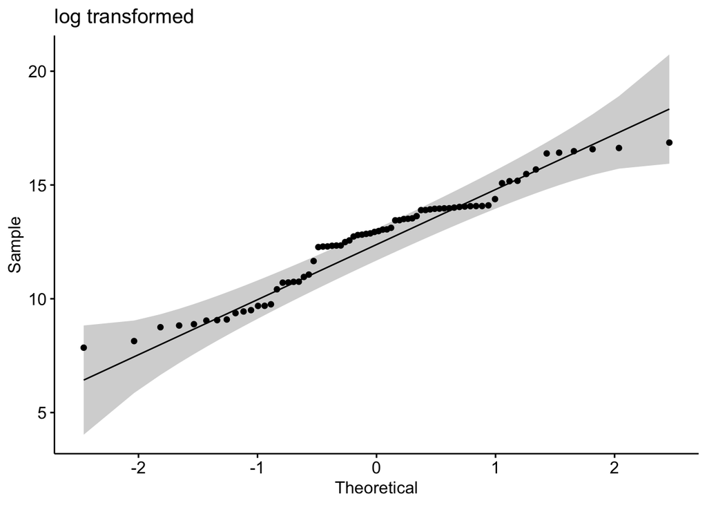

```r
# transformed
ggqqplot(pw_noday0, "log_adh_plus_sup", title = "log transformed") # gorgeous
```

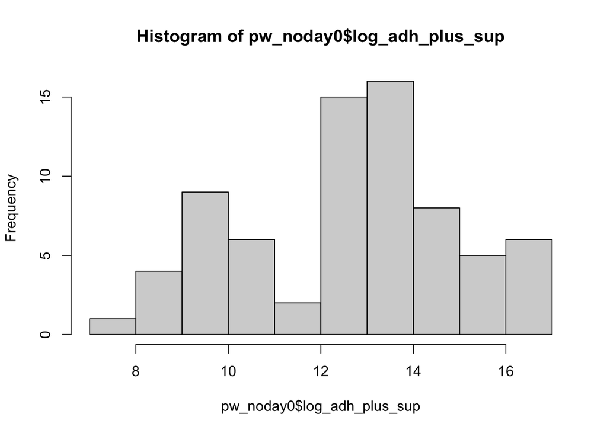

```r
hist(pw_noday0$log_adh_plus_sup) # better
```

```r
shapiro.test(pw_noday0$log_adh_plus_sup) # p-value = 0.01361, does not pass shapiro, but this has an n of 72 which is more than the recommended <50 samples
```

```
    Shapiro-Wilk normality test

data:  pw_noday0$log_adh_plus_sup
W = 0.95623, p-value = 0.01361
```

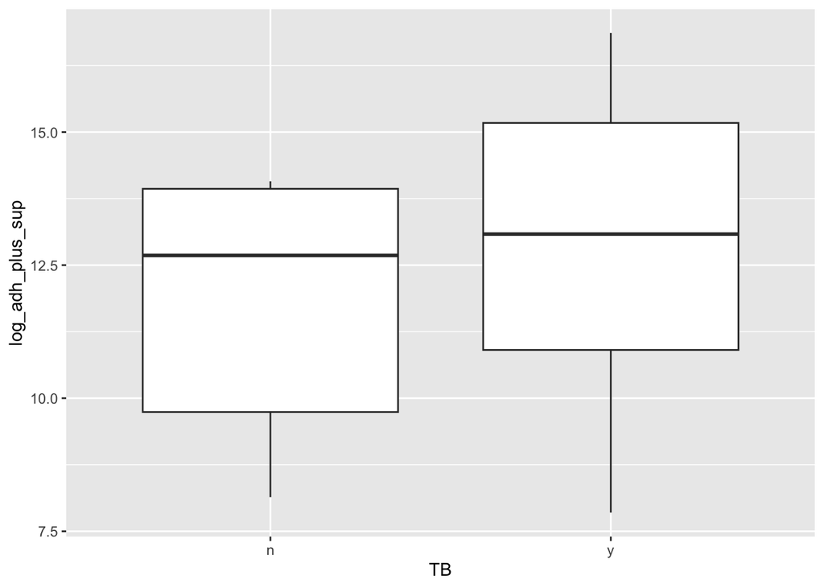

```r
# visualize comparisons
# TB y or n
pw_noday0 %>%
    ggplot(aes(x = TB,
           y = log_adh_plus_sup)) +
  geom_boxplot()
```

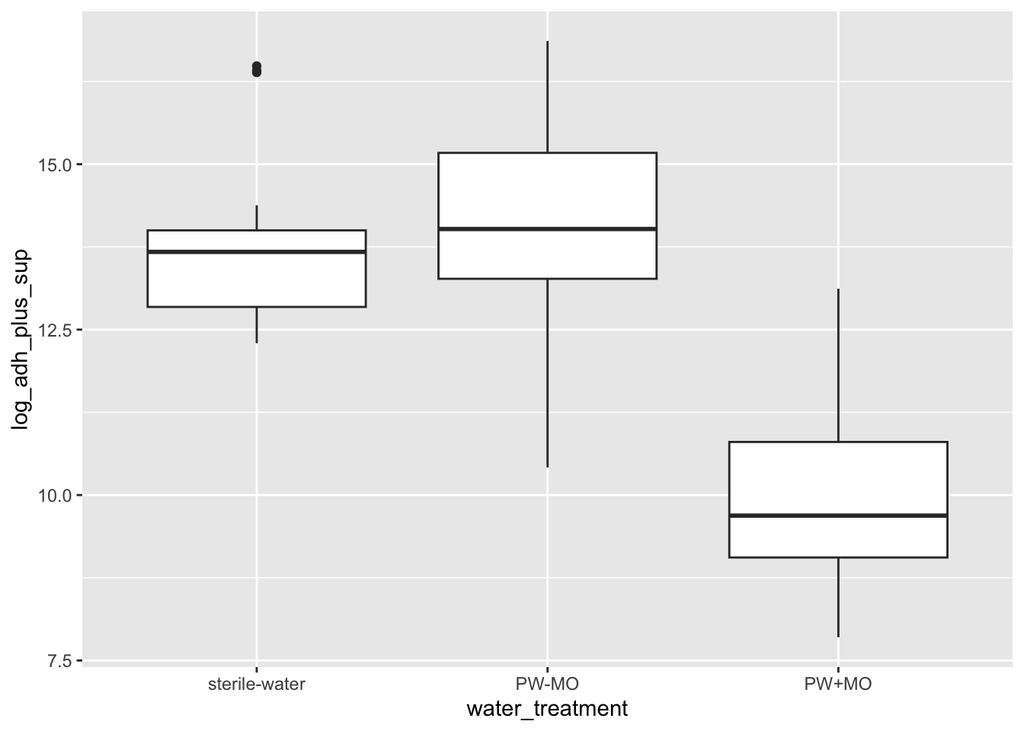

```r
# water_treat
pw_noday0 %>%
    ggplot(aes(x = water_treatment,
           y = log_adh_plus_sup)) +
  geom_boxplot()
```

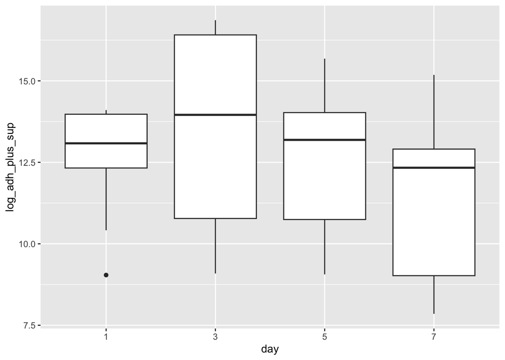

```r
# day
pw_noday0 %>%
    ggplot(aes(x = day,
           y = log_adh_plus_sup)) +
  geom_boxplot()
```

## 2b Stats

TRY ARCSIN

Most appropriate comaprison for study design: day*microbes*water_treatment

- y variable: amount of Bd
- x vars: day, TB y/n, water_treatment (pw with microbes, pw without, sterile water)

Question: Does the amount of Bd in the sample differ across the treatments of presence of water type (pw with microbes, pw without, sterile water), TB, and day?

Model: Linear model

Note: anovas, lm’s and glm’s are all linear models!

## null

```r
null <- lm(log_adh_plus_sup ~ 1,
  data = pw_noday0)
AIC(null) #326.4356
```

```
[1] 326.4356
```

## Try ANOVA with interactions: Bd ~ day*TB*water_treatment

**important: does not pass anova assumption that resids are normally distributed**

I tried different transformations with no luck either :(

Note: Kruskall wallace isn’t the best move here because I want interactions, if I cut the interactions, a normal anova works, so no need for a KW

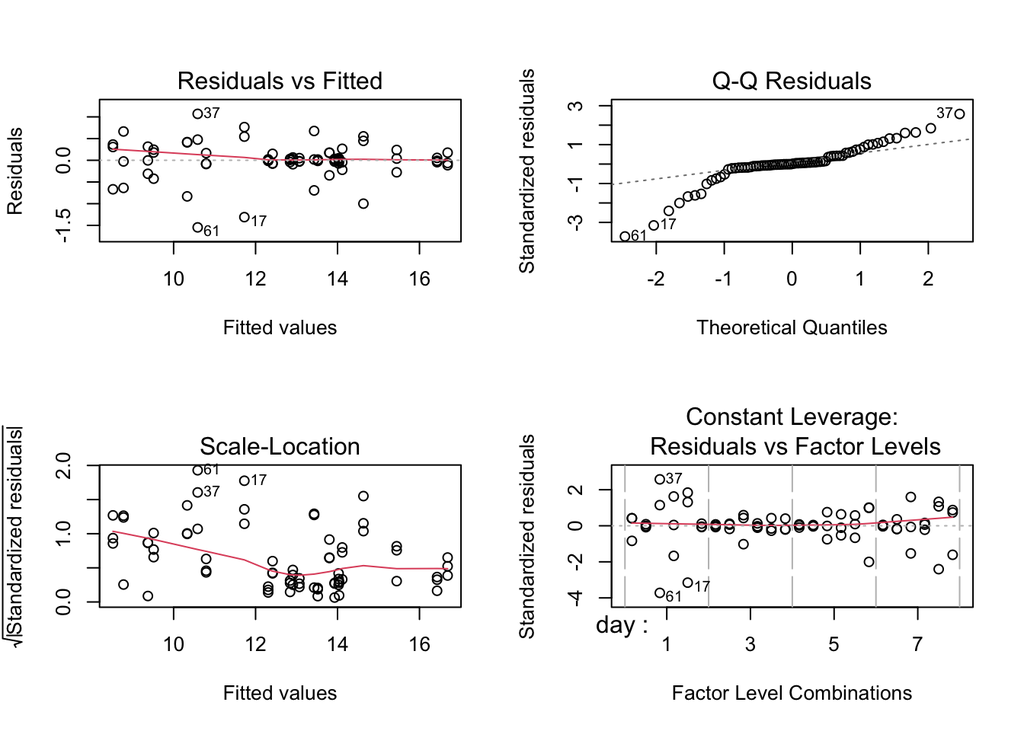

```r
# build model
# all interactions
# read into whether ordered is important!!
mod3 <- aov(log_adh_plus_sup ~ day*TB*water_treatment,
  data = pw_noday0)

# diagnostic plot
par(mfrow = c(2,2))
plot(mod3) # NOT normal...
```

```r
# make qq in car with 95% CI
qqPlot(mod3$residuals)
```

```
[1] 61 17
```

[output not shown]

[figure not shown]

```r
summary(mod3) # 10 out of 70 points falling out "totally passes" for Tatum
```

## GLM Bd ~ day*TB*water_treatment

Normal distribution GLM DOES NOT WORK!!

TRY POISSON OF UNLOGGED DATA, compare aic’s

Cant do a 2 way kruskal wallace

Tatum says its not that severe given the histogram, but try the poisson on the unlogged first!

**Results**

1. Day : Day 3 > Day 1 = Day 5 > Day 7
2. TB: With TB = more Bd than no TB (p <.0001)
3. Water treatment: any treatment with MO has lower Bd, sterile water and microbe free pond water are the same (p = 0.0629), pond water with microorganisms has less Bd than sterile water (p < 0.001), and pond water with MO has less Bd than pond water without (p < 0.001)
4. Interactions are all significant, except TB:water_treatment. I recommend putting these in a table, rather than listing them here, but 5 & 6 summarize them
5. Day and presence of TB: After day 1, there was less Bd in treatments without TB, but on day 1, there was no difference
6. Day and water treatment: across all days, the water treatment trend holds that presence of MO will have lower Bd than without. However, there are nuances between the sterile water and the filtered pond water.
   1. on days 5&7 sterile water had more Bd than pond water without microbes, but on day 1, sterile water had more Bd than pond water with no microbes, but on day 3, there was no difference.

.L and .Q and .C are estimating things for model we do not neeed, turn it off, see the bolker thing Tatum is sending

https://stats.stackexchange.com/questions/387735/interpreting-the-estimate-of-an-ordered-factor-in-regression

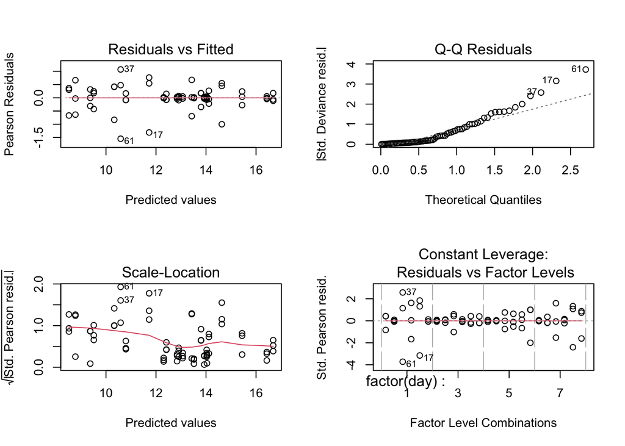

```r
# normal distribution, should be relatively the same as the anova
mod3_glm <- glm(log_adh_plus_sup ~ factor(day) * TB * water_treatment,
                data = pw_noday0,
                family = gaussian(link = "identity"))

par(mfrow = c(2,2))
plot(mod3_glm) # better...but because it is the deviance residuals!!!! this is not comparable to the anova!!
```

```r
summary(mod3_glm)
```

```
Call:
glm(formula = log_adh_plus_sup ~ factor(day) * TB * water_treatment,
    family = gaussian(link = "identity"), data = pw_noday0)

Coefficients:
                                         Estimate Std. Error t value Pr(>|t|)
(Intercept)                             1.322e+01  1.468e-01  90.032  < 2e-16
factor(day).L                          -1.245e+00  2.937e-01  -4.240 0.000101
factor(day).Q                          -3.311e-01  2.937e-01  -1.127 0.265141
factor(day).C                           3.949e-01  2.937e-01   1.345 0.185018
TBy                                     1.001e+00  2.077e-01   4.820 1.49e-05
water_treatmentPW-MO                    2.793e-01  2.077e-01   1.345 0.184881
water_treatmentPW+MO                   -3.658e+00  2.077e-01 -17.615  < 2e-16
factor(day).L:TBy                       3.791e-01  4.153e-01   0.913 0.365895
factor(day).Q:TBy                      -1.772e+00  4.153e-01  -4.266 9.28e-05
factor(day).C:TBy                       1.042e+00  4.153e-01   2.508 0.015563
factor(day).L:water_treatmentPW-MO      4.191e-02  4.153e-01   0.101 0.920050
factor(day).Q:water_treatmentPW-MO     -2.142e-01  4.153e-01  -0.516 0.608344
factor(day).C:water_treatmentPW-MO     -4.170e-01  4.153e-01  -1.004 0.320429
factor(day).L:water_treatmentPW+MO     -2.091e-05  4.153e-01   0.000 0.999960
factor(day).Q:water_treatmentPW+MO      5.709e-01  4.153e-01   1.375 0.175646
factor(day).C:water_treatmentPW+MO     -7.056e-01  4.153e-01  -1.699 0.095803
TBy:water_treatmentPW-MO                1.219e-01  2.937e-01   0.415 0.679970
TBy:water_treatmentPW+MO                1.152e-01  2.937e-01   0.392 0.696566
factor(day).L:TBy:water_treatmentPW-MO  2.495e+00  5.873e-01   4.249 9.83e-05
factor(day).Q:TBy:water_treatmentPW-MO -5.688e-01  5.873e-01  -0.968 0.337717
factor(day).C:TBy:water_treatmentPW-MO  4.639e-01  5.873e-01   0.790 0.433470
factor(day).L:TBy:water_treatmentPW+MO -2.289e+00  5.873e-01  -3.897 0.000301
factor(day).Q:TBy:water_treatmentPW+MO  1.764e+00  5.873e-01   3.003 0.004239
factor(day).C:TBy:water_treatmentPW+MO -1.438e+00  5.873e-01  -2.448 0.018073

(Intercept)                            ***
factor(day).L                          ***
factor(day).Q
factor(day).C
TBy                                    ***
water_treatmentPW-MO
water_treatmentPW+MO                   ***
factor(day).L:TBy
factor(day).Q:TBy                      ***
```

[output cut: 10 more lines]

```
factor(day).Q:TBy:water_treatmentPW-MO
factor(day).C:TBy:water_treatmentPW-MO
factor(day).L:TBy:water_treatmentPW+MO ***
factor(day).Q:TBy:water_treatmentPW+MO **
factor(day).C:TBy:water_treatmentPW+MO *
---
Signif. codes:  0 '***' 0.001 '**' 0.01 '*' 0.05 '.' 0.1 ' ' 1

(Dispersion parameter for gaussian family taken to be 0.2587316)

    Null deviance: 371.319  on 71  degrees of freedom
Residual deviance:  12.419  on 48  degrees of freedom
AIC: 127.79

Number of Fisher Scoring iterations: 2
```

```r
aov_glm_2b <- anova(mod3_glm, test="F") # all interactions are sig except TB:water_treatment
aov_glm_2b
```

```
Analysis of Deviance Table

Model: gaussian, link: identity

Response: log_adh_plus_sup

Terms added sequentially (first to last)

                               Df Deviance Resid. Df Resid. Dev        F
NULL                                              71     371.32
factor(day)                     3   35.401        68     335.92  45.6082
TB                              1   20.990        67     314.93  81.1274
water_treatment                 2  228.848        65      86.08 442.2506
factor(day):TB                  3   11.708        62      74.37  15.0837
factor(day):water_treatment     6   37.330        56      37.04  24.0467
TB:water_treatment              2    0.056        54      36.99   0.1089
factor(day):TB:water_treatment  6   24.566        48      12.42  15.8247
                                  Pr(>F)
NULL
factor(day)                    4.311e-14 ***
TB                             6.924e-12 ***
water_treatment                < 2.2e-16 ***
factor(day):TB                 4.778e-07 ***
factor(day):water_treatment    6.447e-13 ***
TB:water_treatment                 0.897
factor(day):TB:water_treatment 6.303e-10 ***
---
Signif. codes:  0 '***' 0.001 '**' 0.01 '*' 0.05 '.' 0.1 ' ' 1
```

```r
# source for use of anova function on a glm: https://dshizuka.github.io/RCourse/05.1.Stats_LinearModels.html#:~:text=Since%20ANOVA%20is%20a%20linear,to%20get%20the%20F%20statistic.

# all comparisons
em <- emmeans(mod3_glm, ~ day * TB * water_treatment)
# Perform the Tukey test for pairwise comparisons
pairwise_comparisons <- contrast(em, method = "pairwise", adjust = "tukey")
summary(pairwise_comparisons)
```

```
 contrast                                        estimate    SE df t.ratio
 (day1 n sterile-water) - (day3 n sterile-water)  -0.1275 0.415 48  -0.307
 (day1 n sterile-water) - (day5 n sterile-water)   0.9592 0.415 48   2.310
 (day1 n sterile-water) - (day7 n sterile-water)   1.4940 0.415 48   3.597
 (day1 n sterile-water) - (day1 y sterile-water)   0.3724 0.415 48   0.897
 (day1 n sterile-water) - (day3 y sterile-water)  -2.6283 0.415 48  -6.329
 (day1 n sterile-water) - (day5 y sterile-water)  -0.3135 0.415 48  -0.755
 (day1 n sterile-water) - (day7 y sterile-water)   0.8918 0.415 48   2.147
 (day1 n sterile-water) - (day1 n PW-MO)          -0.2374 0.415 48  -0.571
 (day1 n sterile-water) - (day3 n PW-MO)          -0.2249 0.415 48  -0.541
 (day1 n sterile-water) - (day5 n PW-MO)           0.2837 0.415 48   0.683
 (day1 n sterile-water) - (day7 n PW-MO)           1.3869 0.415 48   3.339
 (day1 n sterile-water) - (day1 y PW-MO)           2.0753 0.415 48   4.997
 (day1 n sterile-water) - (day3 y PW-MO)          -2.8852 0.415 48  -6.947
 (day1 n sterile-water) - (day5 y PW-MO)          -1.6421 0.415 48  -3.954
 (day1 n sterile-water) - (day7 y PW-MO)          -0.8305 0.415 48  -2.000
 (day1 n sterile-water) - (day1 n PW+MO)           3.2147 0.415 48   7.740
 (day1 n sterile-water) - (day3 n PW+MO)           4.2892 0.415 48  10.328
 (day1 n sterile-water) - (day5 n PW+MO)           4.4292 0.415 48  10.665
 (day1 n sterile-water) - (day7 n PW+MO)           5.0242 0.415 48  12.097
 (day1 n sterile-water) - (day1 y PW+MO)           0.7330 0.415 48   1.765
 (day1 n sterile-water) - (day3 y PW+MO)           3.0076 0.415 48   7.242
 (day1 n sterile-water) - (day5 y PW+MO)           3.4704 0.415 48   8.356
 (day1 n sterile-water) - (day7 y PW+MO)           5.2821 0.415 48  12.718
 (day3 n sterile-water) - (day5 n sterile-water)   1.0867 0.415 48   2.617
 (day3 n sterile-water) - (day7 n sterile-water)   1.6215 0.415 48   3.904
 (day3 n sterile-water) - (day1 y sterile-water)   0.4999 0.415 48   1.204
 (day3 n sterile-water) - (day3 y sterile-water)  -2.5009 0.415 48  -6.022
 (day3 n sterile-water) - (day5 y sterile-water)  -0.1860 0.415 48  -0.448
 (day3 n sterile-water) - (day7 y sterile-water)   1.0193 0.415 48   2.454
 (day3 n sterile-water) - (day1 n PW-MO)          -0.1099 0.415 48  -0.265
 (day3 n sterile-water) - (day3 n PW-MO)          -0.0974 0.415 48  -0.234
 (day3 n sterile-water) - (day5 n PW-MO)           0.4112 0.415 48   0.990
 (day3 n sterile-water) - (day7 n PW-MO)           1.5143 0.415 48   3.646
 (day3 n sterile-water) - (day1 y PW-MO)           2.2028 0.415 48   5.304
 (day3 n sterile-water) - (day3 y PW-MO)          -2.7577 0.415 48  -6.640
 (day3 n sterile-water) - (day5 y PW-MO)          -1.5146 0.415 48  -3.647
 (day3 n sterile-water) - (day7 y PW-MO)          -0.7030 0.415 48  -1.693
 (day3 n sterile-water) - (day1 n PW+MO)           3.3421 0.415 48   8.047
 (day3 n sterile-water) - (day3 n PW+MO)           4.4167 0.415 48  10.634
```

[output cut: 501 more lines]

```
  0.1434
  0.7926
  0.9128
  <.0001
  0.0027
  0.0670
  1.0000
  0.0004
  <.0001
  <.0001
  1.0000
  0.0004
  0.0121

P value adjustment: tukey method for comparing a family of 24 estimates
```

```r
## First order comparisons

# Pairwise comparisons for 'day'
# Day 3 > Day 1 = Day 5 > Day 7
pairwise_day_2b <- emmeans(mod3_glm, pairwise ~ day, adjust = "tukey")
```

```
NOTE: Results may be misleading due to involvement in interactions
```

```r
pairwise_day_2b
```

```
$emmeans
 day emmean   SE df lower.CL upper.CL
 1     12.8 0.12 48     12.5     13.0
 3     13.6 0.12 48     13.3     13.8
 5     12.6 0.12 48     12.4     12.8
 7     11.6 0.12 48     11.4     11.8

Results are averaged over the levels of: TB, water_treatment
Confidence level used: 0.95

$contrasts
 contrast    estimate   SE df t.ratio p.value
 day1 - day3   -0.788 0.17 48  -4.647  0.0002
 day1 - day5    0.172 0.17 48   1.012  0.7435
 day1 - day7    1.182 0.17 48   6.970  <.0001
 day3 - day5    0.959 0.17 48   5.658  <.0001
 day3 - day7    1.970 0.17 48  11.616  <.0001
 day5 - day7    1.010 0.17 48   5.958  <.0001

Results are averaged over the levels of: TB, water_treatment
P value adjustment: tukey method for comparing a family of 4 estimates
```

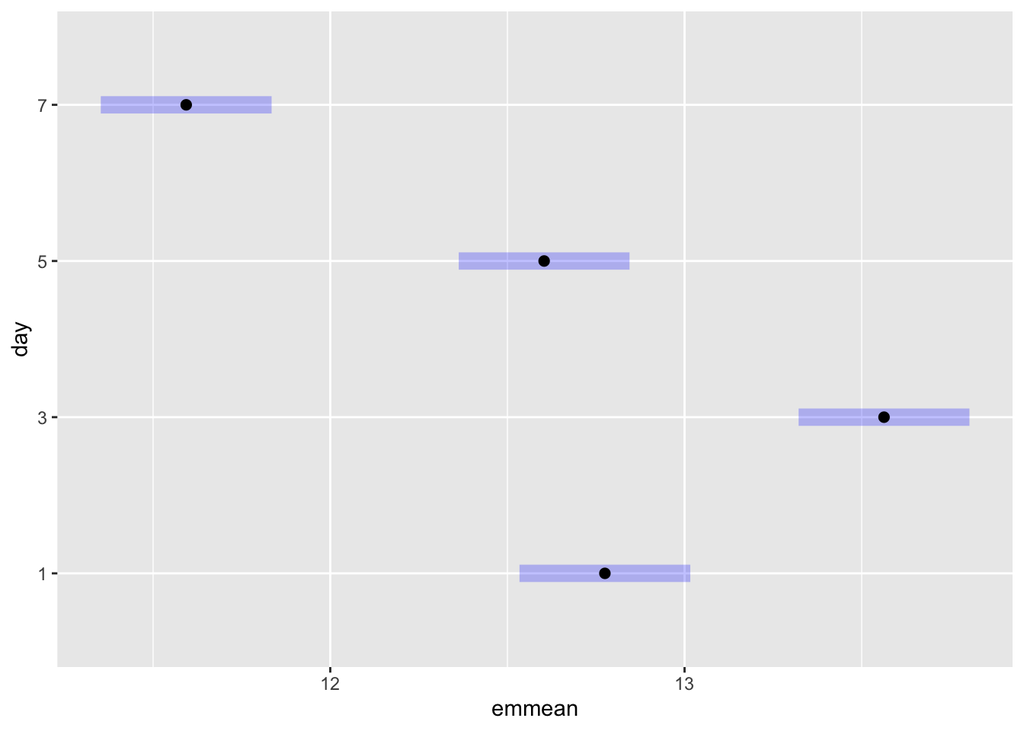

```r
plot(pairwise_day_2b)
```

```r
# Pairwise comparisons for 'TB'
# note I dont need to test this bc its only 2 levels, bc I am "wasting" df
# or bonferroni comparisons by hand is another option
pairwise_TB_2b <- emmeans(mod3_glm, pairwise ~ TB, adjust = "tukey")
```

```
NOTE: Results may be misleading due to involvement in interactions
```

```r
pairwise_TB_2b
```

```
$emmeans
 TB emmean     SE df lower.CL upper.CL
 n    12.1 0.0848 48     11.9     12.3
 y    13.2 0.0848 48     13.0     13.3

Results are averaged over the levels of: day, water_treatment
Confidence level used: 0.95

$contrasts
 contrast estimate   SE df t.ratio p.value
 n - y       -1.08 0.12 48  -9.007  <.0001

Results are averaged over the levels of: day, water_treatment
```